# Regression Analysis and Diagnostics

Hriday Baghar

# Loading Dataset

```
'data.frame':   32971 obs. of  25 variables:
 $ X                           : int  0 1 2 3 4 5 6 7 8 9 ...
 $ Day.of.Week                 : Factor w/ 7 levels "Friday","Monday",..: 1 1 1 1 1 1 1 1 1 1 ...
 $ Category                    : Factor w/ 6 levels "Business","Entertainment",..: 6 6 6 6 6 6 6 6 6 6 ...
 $ n_tokens_title              : int  8 9 10 11 14 11 10 8 13 10 ...
 $ n_tokens_content            : int  461 537 331 877 696 291 416 208 742 322 ...
 $ n_unique_tokens             : num  5.5 5.04 6.49 4.34 4.8 ...
 $ n_non_stop_unique_tokens    : num  7.05 6.02 8.13 5.84 7.43 ...
 $ num_hrefs                   : int  8 3 8 45 5 9 8 4 12 9 ...
 $ num_imgs                    : int  1 13 1 1 1 1 0 1 1 1 ...
 $ num_videos                  : int  0 0 0 1 0 0 0 0 0 2 ...
 $ average_token_length        : num  5.08 4.88 5.12 5.1 4.02 ...
 $ num_keywords                : int  5 9 6 8 7 7 6 8 6 10 ...
 $ global_subjectivity         : num  5.4 5.43 3.64 4.88 3.99 ...
 $ global_sentiment_polarity   : num  0.8932 0.5018 1.3834 2.7705 0.0067 ...
 $ global_rate_positive_words  : num  0.347 0.261 0.423 0.593 0.244 ...
 $ global_rate_negative_words  : num  0.217 0.205 0.242 0.308 0.388 ...
 $ rate_positive_words         : num  6.15 5.6 6.36 6.58 3.86 ...
 $ rate_negative_words         : num  3.85 4.4 3.64 3.42 6.14 ...
 $ avg_positive_polarity       : num  3.81 4.58 3.95 6.03 3.73 ...
 $ avg_negative_polarity       : num  -2.48 -4.37 -1.9 -2.29 -2.34 ...
 $ title_subjectivity          : num  7.5 10 0 4.75 4.33 ...
 $ title_sentiment_polarity    : num  -2.5 -1.25 0 3.75 -1.67 ...
 $ abs_title_subjectivity      : num  2.5 5 5 0.25 0.667 ...
 $ abs_title_sentiment_polarity: num  2.5 1.25 0 3.75 1.67 ...
 $ shares                      : int  1100 2500 614 1100 720 1600 2100 2200 465 2200 ...
```

# Exploring correlated features

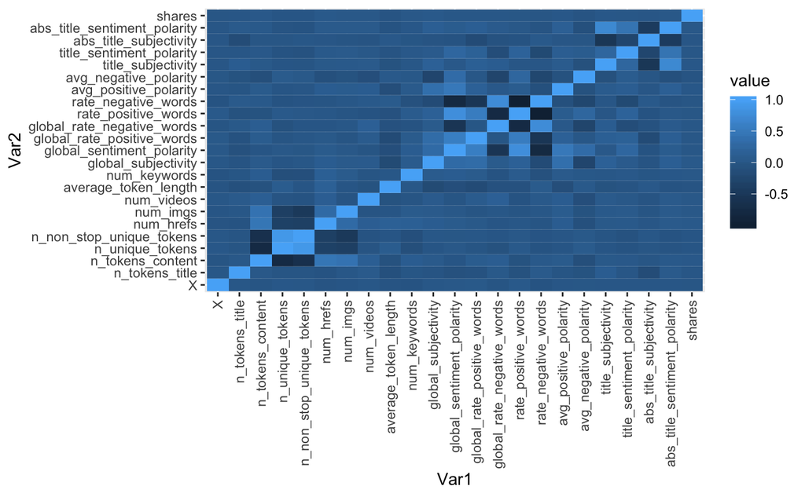

We should drop highly correlated features so as to not run into multi-collinearity. Here are some selections we will make for highly correlated variables:

- rate positive words, rate negative words, polarity: polarity will be used

# Regression model

## Base model

```
Call:
lm(formula = shares ~ Day.of.Week + Category + n_tokens_title +
    n_tokens_content + num_hrefs + num_imgs + num_videos + average_token_length +
    global_subjectivity + global_sentiment_polarity + title_sentiment_polarity,
    data = data)

Residuals:
   Min     1Q Median     3Q    Max
 -7602  -1945  -1272   -278 686194

Coefficients:
                           Estimate Std. Error t value Pr(>|t|)
(Intercept)               4483.1002  1156.7987   3.875 0.000107 ***
Day.of.WeekMonday          347.6150   187.5558   1.853 0.063835 .
Day.of.WeekSaturday        499.7372   254.6355   1.963 0.049706 *
Day.of.WeekSunday          645.6289   248.4593   2.599 0.009367 **
Day.of.WeekThursday          3.2226   184.7466   0.017 0.986083
Day.of.WeekTuesday          16.6298   184.0619   0.090 0.928010
Day.of.WeekWednesday         2.9986   183.5877   0.016 0.986969
CategoryEntertainment     -604.5440   175.8419  -3.438 0.000587 ***
CategoryLifestyle          180.2986   244.3655   0.738 0.460627
CategorySocial Media       262.8241   233.7929   1.124 0.260947
CategoryTech              -207.8870   166.8720  -1.246 0.212851
CategoryWorld             -788.0536   165.6897  -4.756 1.98e-06 ***
n_tokens_title              38.3485    25.1239   1.526 0.126926
n_tokens_content             0.0474     0.1329   0.357 0.721292
num_hrefs                   30.8383     5.8472   5.274 1.34e-07 ***
num_imgs                    17.1135     7.9111   2.163 0.030532 *
num_videos                  45.3519    14.9253   3.039 0.002379 **
average_token_length      -846.0982   214.8360  -3.938 8.22e-05 ***
global_subjectivity        435.2836    68.9411   6.314 2.76e-10 ***
global_sentiment_polarity -191.7845    65.1392  -2.944 0.003240 **
title_sentiment_polarity    34.3238    21.4674   1.599 0.109857
---
Signif. codes:  0 ‘***’ 0.001 ‘**’ 0.01 ‘*’ 0.05 ‘.’ 0.1 ‘ ’ 1

Residual standard error: 9483 on 32950 degrees of freedom
Multiple R-squared:  0.007019,  Adjusted R-squared:  0.006416
F-statistic: 11.65 on 20 and 32950 DF,  p-value: < 2.2e-16
```

Testing model assumptions

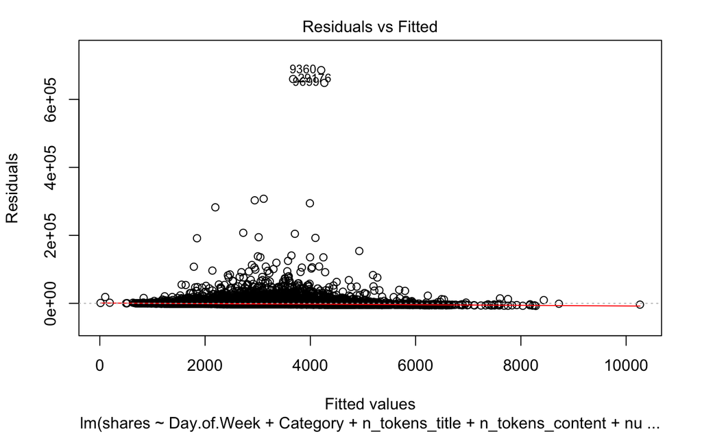

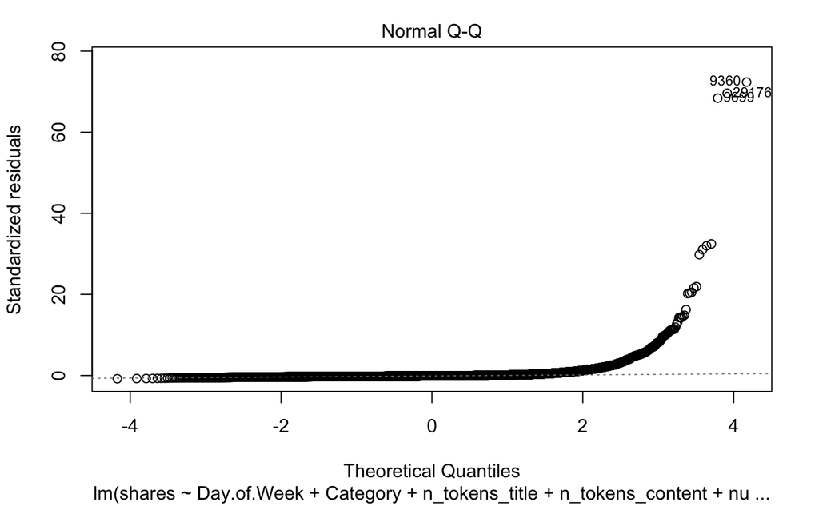

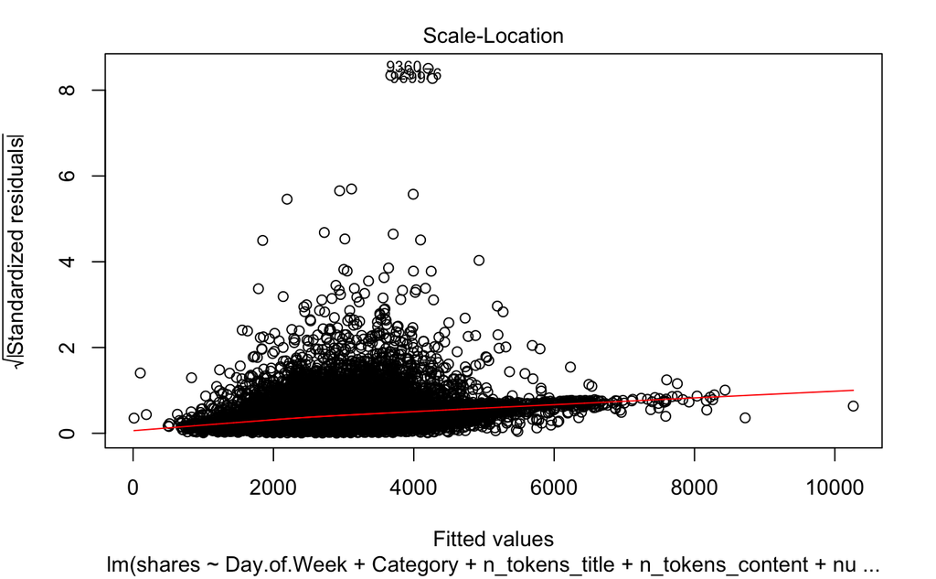

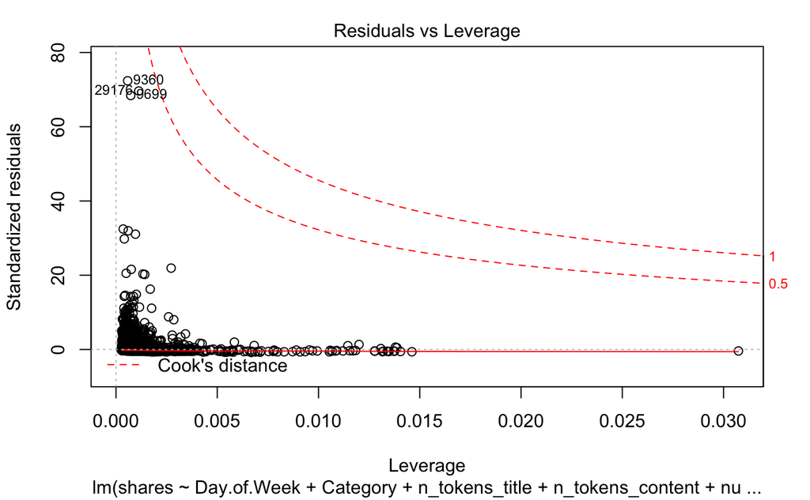

We observe the following:

- It is not clear if linearity holds, the range of residuals is very high
- Constant varaince assumption does not appear to be met

# Regression model with log transformed target variable

Testing model assumptions for target variable converted to log:

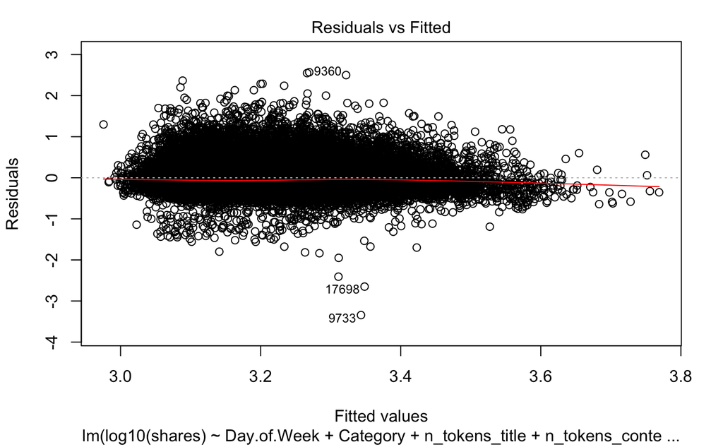

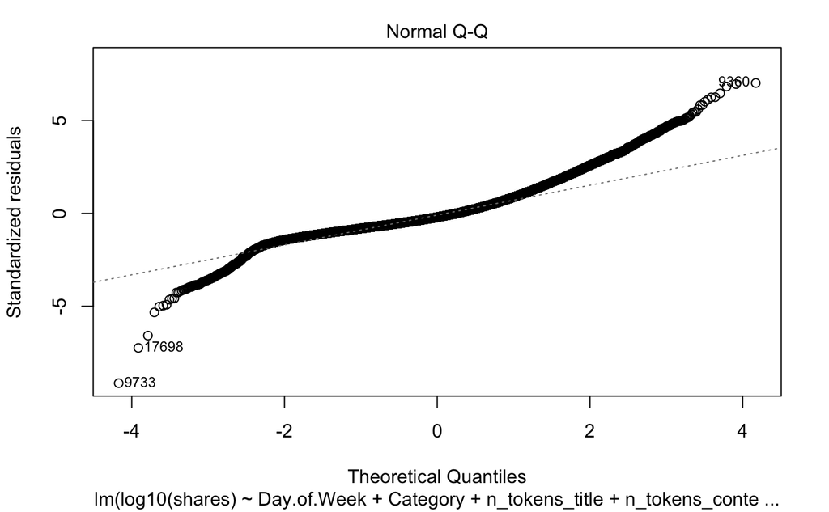

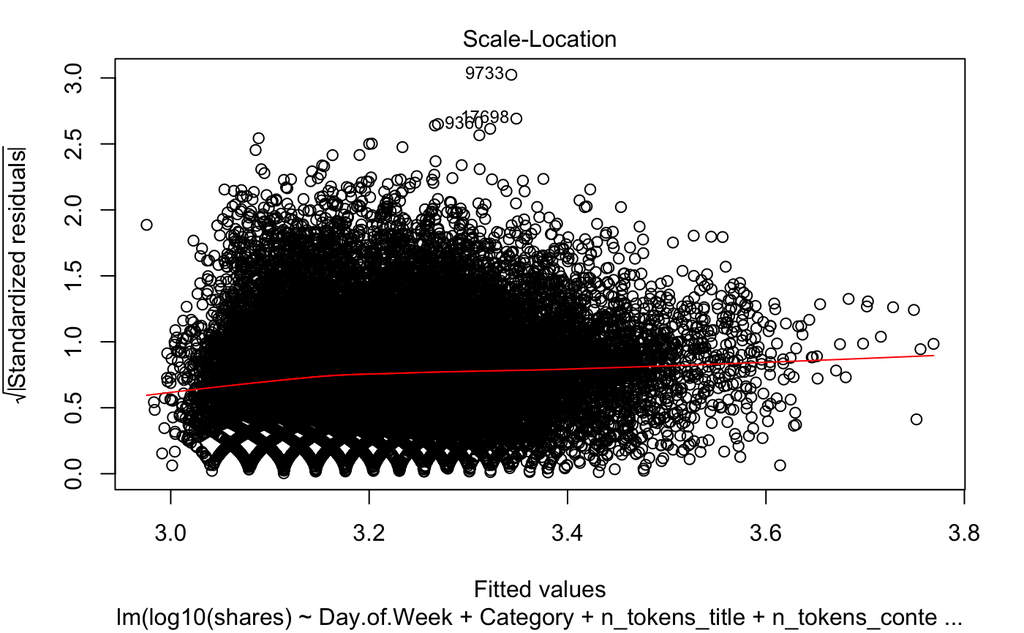

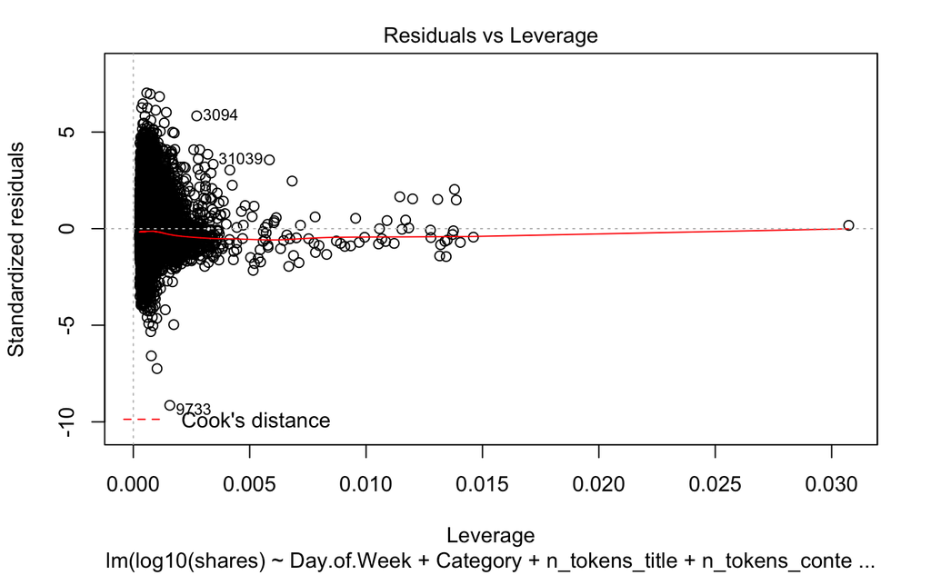

The assumptions of linearity and constant variance appear to be fulfilled for this model.